# **Definisi Queues**

# **Code**

```python
def ularNaga(nama, hitungan):
    gameQueue = createQueue()
    for namaAnak in nama:
        enqueue(gameQueue,namaAnak)
    print('Peserta Permainan=',gameQueue)
    while size(gameQueue) > 1:
        for i in range(hitungan):
            enqueue(gameQueue,dequeue(gameQueue))
            print('hitungan ke-',i,'=',gameQueue)
        dequeue(gameQueue)
        print('Peserta Permainan=',gameQueue)
    return dequeue(gameQueue)
```

# **Queues**

**Struktur Data Antrian**

adalah konsep fundamental dalam ilmu komputer yang digunakan untuk menyimpan dan mengelola data dalam urutan tertentu.

- Sistem ini mengikuti prinsip " Masuk Pertama, Keluar Pertama " (FIFO) , di mana elemen pertama yang ditambahkan ke antrian adalah elemen pertama yang dikeluarkan.
- Ini digunakan sebagai penyangga dalam sistem komputer ketika terjadi ketidaksesuaian kecepatan antara dua perangkat yang saling berkomunikasi. Misalnya, CPU dan keyboard, dua perangkat dalam jaringan.
- Antrian juga digunakan dalam algoritma Sistem Operasi seperti Penjadwalan CPU dan Manajemen Memori, serta banyak algoritma standar seperti Pencarian Lebar Pertama pada Graf, Penelusuran Urutan Level pada Pohon.

Antrian adalah struktur data linier yang mengikuti prinsip Masuk Pertama Keluar Pertama (FIFO).

**Antrian**

Bayangkan antrean seperti orang-orang yang berdiri berbaris di supermarket.

Orang pertama yang mengantre juga merupakan orang pertama yang dapat membayar dan meninggalkan supermarket.

Operasi dasar yang dapat kita lakukan pada antrian adalah:

- **Enqueue:** Menambahkan elemen baru ke dalam antrian.
- **Dequeue:** Menghapus dan mengembalikan elemen pertama (terdepan) dari antrian.
- **Peek:** Mengembalikan elemen pertama dalam antrian.
- **isEmpty:** Memeriksa apakah antrian kosong.
- **Ukuran:** Menemukan jumlah elemen dalam antrian.
- Antrian dapat diimplementasikan dengan menggunakan array atau linked list.

Antrian dapat digunakan untuk mengimplementasikan penjadwalan pekerjaan untuk printer kantor, pemrosesan pesanan untuk tiket elektronik, atau untuk membuat algoritma pencarian breadth-first dalam grafik.

Antrian (queue) adalah struktur data linier yang mengikuti Prinsip FIFO (First In First Out), sehingga elemen pertama yang dimasukkan adalah elemen pertama yang dikeluarkan.

- Ini adalah daftar terurut di mana penyisipan dilakukan di salah satu ujung yang dikenal sebagai belakang dan penghapusan dilakukan dari ujung lainnya yang dikenal sebagai depan.
- Contoh yang baik dari antrian adalah antrian konsumen untuk suatu sumber daya, di mana konsumen yang datang pertama akan dilayani terlebih dahulu.
- Perbedaan antara stack dan queue terletak pada cara menghapus elemen. Pada stack, kita menghapus elemen yang paling baru ditambahkan, sedangkan pada queue, kita menghapus elemen yang paling lama ditambahkan.

**Prinsip FIFO dalam Antrian:**

Prinsip FIFO menyatakan bahwa elemen pertama yang ditambahkan ke antrian akan menjadi elemen pertama yang dikeluarkan atau diproses. Jadi, antrian seperti barisan orang yang menunggu untuk membeli tiket, di mana orang pertama dalam barisan adalah orang pertama yang dilayani (yaitu, siapa cepat dia dapat).

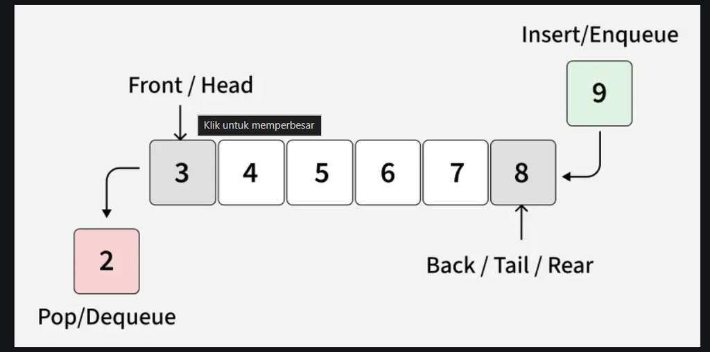

**Terminologi Dasar Antrian**

Depan: Posisi entri dalam antrian yang siap dilayani, yaitu entri pertama yang akan dikeluarkan dari antrian, disebut depan antrian. Ini juga disebut sebagai kepala antrian.

Belakang: Posisi entri terakhir dalam antrian, yaitu yang paling baru ditambahkan, disebut belakang antrian. Ini juga disebut sebagai ekor antrian.

Ukuran: Ukuran mengacu pada jumlah elemen yang ada dalam antrian saat ini.

Kapasitas: Kapasitas mengacu pada jumlah maksimum elemen yang dapat ditampung oleh antrian.

**Jenis-jenis Antrian** Struktur data antrian dapat diklasifikasikan menjadi 3 jenis:

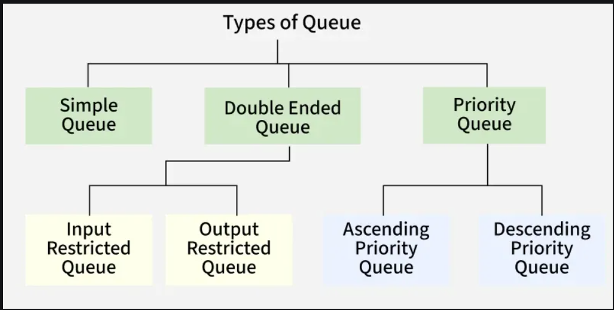

**1. Antrian Sederhana**

Antrian sederhana mengikuti prinsip FIFO (First In, First Out).

- Penyisipan hanya diperbolehkan di bagian belakang.
- Penghapusan hanya diperbolehkan dari depan.
- Dapat diimplementasikan menggunakan linked list atau circular array.

Saat menggunakan array, kita sering lebih memilih antrian melingkar (circular queue ), yang pada dasarnya merupakan implementasi array yang efisien dari antrian sederhana. Antrian ini memanfaatkan memori secara efisien dengan menggunakan kembali ruang kosong yang tersisa setelah penghapusan, menghindari pemborosan yang terjadi pada implementasi array linier biasa.

**2. Antrian Dua Ujung (Deque)**

Dalam sebuah deque, penyisipan dan penghapusan dapat dilakukan dari kedua ujungnya.

**3. Antrian Prioritas** Antrian di mana setiap elemen diberi prioritas , dan penghapusan selalu terjadi berdasarkan prioritas (bukan hanya posisi).

**Operasi Antrian**

1. Enqueue : Menambahkan elemen ke ujung (belakang) antrian. Jika antrian penuh, akan terjadi kesalahan overflow.
2. Dequeue : Menghapus elemen dari bagian depan antrian. Jika antrian kosong, terjadi kesalahan underflow.
3. Peek/Front : Mengembalikan elemen yang berada di depan tanpa menghapusnya
4. Ukuran : Mengembalikan jumlah elemen dalam antrian.
5. isEmpty : Mengembalikan nilai true jika antrean kosong, jika tidak, mengembalikan nilai false.
6. isFull : Mengembalikan nilai true jika antrean penuh, jika tidak, mengembalikan nilai false.

**Implementasi Antrian menggunakan Daftar Python**

Untuk daftar (dan array) Python, sebuah Queue dapat terlihat dan berperilaku seperti ini:

x = [5, 6, 2, 9, 3, 8, 4, 2]

Karena list Python memiliki dukungan yang baik untuk fungsionalitas yang dibutuhkan untuk mengimplementasikan antrian, kita mulai dengan membuat antrian dan melakukan operasi antrian hanya dengan beberapa baris kode:

```python
#Menggunakan list Python sebagai antrian:

#queue = []

# Enqueue
queue.append('A')
queue.append('B')
queue.append('C')
print("Queue: ", queue)

# Peek
frontElement = queue[0]
print("Peek: ", frontElement)

# Dequeue
poppedElement = queue.pop(0)
print("Dequeue: ", poppedElement)

print("Queue after Dequeue: ", queue)

# isEmpty
isEmpty = not bool(queue)
print("isEmpty: ", isEmpty)

# Size
print("Size: ", len(queue))
```

```python
#Menggunakan kelas Python sebagai antrian:

class Queue:
  def __init__(self):
    self.queue = []

  def enqueue(self, element):
    self.queue.append(element)

  def dequeue(self):
    if self.isEmpty():
      return "Queue is empty"
    return self.queue.pop(0)

  def peek(self):
    if self.isEmpty():
      return "Queue is empty"
    return self.queue[0]

  def isEmpty(self):
    return len(self.queue) == 0

  def size(self):
    return len(self.queue)

# Create a queue
myQueue = Queue()

myQueue.enqueue('A')
myQueue.enqueue('B')
myQueue.enqueue('C')

print("Queue: ", myQueue.queue)
print("Peek: ", myQueue.peek())
print("Dequeue: ", myQueue.dequeue())
print("Queue after Dequeue: ", myQueue.queue)
print("isEmpty: ", myQueue.isEmpty())
print("Size: ", myQueue.size())
```

**Implementasi Antrian menggunakan Daftar Berantai**

Sebuah linked list terdiri dari node yang berisi data tertentu, dan sebuah pointer ke node berikutnya.

Salah satu keuntungan besar menggunakan linked list adalah node disimpan di mana pun ada ruang kosong di memori, node tidak perlu disimpan berdekatan satu sama lain seperti elemen yang disimpan dalam array. Keuntungan lain dari linked list adalah ketika menambahkan atau menghapus node, node lain dalam list tidak perlu digeser.

Beginilah cara mengimplementasikan antrian menggunakan linked list.

```python
#Membuat Antrian menggunakan Daftar Tertaut:

class Node:
  def __init__(self, data):
    self.data = data
    self.next = None

class Queue:
  def __init__(self):
    self.front = None
    self.rear = None
    self.length = 0

  def enqueue(self, element):
    new_node = Node(element)
    if self.rear is None:
      self.front = self.rear = new_node
      self.length += 1
      return
    self.rear.next = new_node
    self.rear = new_node
    self.length += 1

  def dequeue(self):
    if self.isEmpty():
      return "Queue is empty"
    temp = self.front
    self.front = temp.next
    self.length -= 1
    if self.front is None:
      self.rear = None
    return temp.data

  def peek(self):
    if self.isEmpty():
      return "Queue is empty"
    return self.front.data

  def isEmpty(self):
    return self.length == 0

  def size(self):
    return self.length

  def printQueue(self):
    temp = self.front
    while temp:
      print(temp.data, end=" -> ")
      temp = temp.next
    print()

# Create a queue
myQueue = Queue()

myQueue.enqueue('A')
myQueue.enqueue('B')
myQueue.enqueue('C')

print("Queue: ", end="")
myQueue.printQueue()
print("Peek: ", myQueue.peek())
print("Dequeue: ", myQueue.dequeue())
print("Queue after Dequeue: ", end="")
myQueue.printQueue()
print("isEmpty: ", myQueue.isEmpty())
print("Size: ", myQueue.size())
```

Alasan menggunakan linked list untuk mengimplementasikan antrian:

- Ukuran dinamis: Antrian dapat bertambah besar dan kecil secara dinamis, tidak seperti pada array.
- Tidak ada pergeseran: Elemen terdepan dalam antrian dapat dihapus (dimasukkan ke antrian) tanpa harus menggeser elemen lain dalam memori.

Alasan mengapa linked list tidak digunakan untuk mengimplementasikan antrian:

- Memori tambahan: Setiap elemen antrian harus berisi alamat ke elemen berikutnya (node daftar tertaut berikutnya).
- Keterbacaan: Kode ini mungkin lebih sulit dibaca dan ditulis bagi sebagian orang karena lebih panjang dan lebih kompleks.

## **Latihan Pilgan Queue**

**1. Struktur data Queue mengikuti prinsip kerja yang disebut dengan...**

A. LIFO

B. LILO

C. FIFO

D. FILO

**Jawaban: C (FIFO)**

Penjelasan: Queue bersifat FIFO (First In First Out), artinya data yang pertama kali masuk adalah yang pertama kali keluar.

**2. Pada antrean (Queue), operasi untuk menambahkan elemen ke posisi paling belakang disebut...**

A. Enqueue

B. Dequeue

C. Peek

D. Pop

**Jawaban: A (Enqueue)**

Penjelasan: Enqueue digunakan untuk menambah data ke ujung belakang (rear), sedangkan Dequeue untuk mengambil data dari depan (front).

**3. Apa perbedaan utama antara Queue biasa dengan Deque?**

A. Queue hanya bisa akses satu sisi, Deque bisa akses kedua sisi

B. Deque lebih cepat daripada Queue

C. Queue tidak menggunakan list

D. Deque hanya bisa menyimpan tipe data angka

**Jawaban: A (Queue hanya bisa akses satu sisi, Deque bisa akses kedua sisi)**

Penjelasan: Deque (Double-Ended Queue) memungkinkan penambahan dan penghapusan data dari kedua ujung (depan dan belakang).

**4. Jika kita memiliki antrean [10, 20, 30] dan melakukan satu kali operasi dequeue, elemen mana yang terambil?**

A. 30

B. 10

C. 20

D. Tidak bisa diambil

**Jawaban: B (10)**

Penjelasan: Karena prinsip FIFO, elemen yang berada di posisi depan (indeks 0) adalah yang pertama kali keluar.

**5. Manakah fungsi di Python yang paling tepat untuk efisiensi tinggi pada Deque?

A. list.append()

B. list.pop(0)

C. collections.deque

D. list.insert()

**Jawaban: C (collections.deque)**

Penjelasan: Modul collections.deque dirancang khusus untuk operasi penambahan/pengurangan di kedua ujung dengan kompleksitas $O(1)$.

# **LATIHAN CODE**

**Soal 1: Sistem Antrean Tiket dengan Validasi**

Program ini memastikan antrean tidak diproses jika kosong.

```python
antrean = []

def enqueue(q, orang):
    q.append(orang)
    print(f"{orang} telah masuk antrean.")

def dequeue(q):
    if len(q) == 0:
        print("Error: Antrean kosong, tidak ada yang bisa dilayani.")
    else:
        dilayani = q.pop(0)
        print(f"Melayani: {dilayani}")

enqueue(antrean, "Zaka")
enqueue(antrean, "Aisyah")
dequeue(antrean)
dequeue(antrean)
dequeue(antrean) # Mengetes kondisi error
```

**soal 2: Deque dengan Operasi Sisi Ganda**

Menampilkan fungsi add_front, add_rear, remove_front, dan remove_rear.

```python
dq = []

def add_f(d, val): d.insert(0, val)
def add_r(d, val): d.append(val)
def rem_f(d): return d.pop(0) if d else "Kosong"
def rem_r(d): return d.pop() if d else "Kosong"

add_r(dq, "Tengah")
add_f(dq, "Depan")
add_r(dq, "Belakang")
print(f"Status Deque: {dq}")
print(f"Hapus depan: {rem_f(dq)}")
print(f"Status Akhir: {dq}")
```

**Soal 3: Simulasi Antrean Server Web (Max Capacity)**

Membatasi jumlah antrean agar tidak terjadi overflow.

```python
server_queue = []
MAX_SIZE = 3

def tambah_job(job):
    if len(server_queue) < MAX_SIZE:
        server_queue.append(job)
        print(f"Job '{job}' masuk antrean.")
    else:
        print(f"Server sibuk! Job '{job}' ditolak.")

tambah_job("Request_1")
tambah_job("Request_2")
tambah_job("Request_3")
tambah_job("Request_4") # Akan tertolak
```

**Soal 4: Menghapus Elemen Tertentu dalam Antrean**

Mencari dan menghapus nama orang tertentu di tengah antrean.

```python
antrean = ["Zaka", "Budi", "Siti", "Andi"]
target = "Siti"

if target in antrean:
    antrean.remove(target)
    print(f"{target} telah keluar dari antrean secara manual.")
else:
    print("Orang tidak ditemukan.")
print(f"Antrean sekarang: {antrean}")
```

**Soal 5: Pembalikkan Antrean Menggunakan Stack**

Mengubah urutan antrean menjadi terbalik (teknik populer di soal UAS).

```python
queue = [10, 20, 30, 40]
stack = []

print(f"Antrean awal: {queue}")
while queue:
    stack.append(queue.pop(0))
while stack:
    queue.append(stack.pop())
print(f"Antrean setelah dibalik: {queue}")
```

**Soal 6: Cek Palindrom dengan Deque (Logika Lengkap)**

Versi lebih detail yang mengecek karakter satu per satu.

```python
def is_palindrom(kata):
    dq = list(kata.lower())
    while len(dq) > 1:
        depan = dq.pop(0)
        belakang = dq.pop()
        if depan != belakang:
            return False
    return True

teks = "Malam"
print(f"Apakah '{teks}' palindrom? {is_palindrom(teks)}")
```

**Soal 7: Antrean Prioritas (Menyisip di Tengah)**

Menyisipkan orang berdasarkan kondisi tertentu (misal: Lansia).

```python
antrean = ["Orang1", "Orang2", "Orang3"]
def insert_lansia(q, orang):
    # Menyisip setelah orang pertama sebagai prioritas
    q.insert(1, orang)
    print(f"{orang} disisipkan sebagai prioritas.")

insert_lansia(antrean, "Lansia_A")
print(f"Antrean: {antrean}")
```

**Soal 8: Sistem Rotasi Antrean (Round Robin)**

Memindahkan elemen depan ke posisi paling belakang (sering dipakai di OS).

```python
antrean = ["Task A", "Task B", "Task C"]

def rotasi(q):
    if q:
        item = q.pop(0)
        q.append(item)
        print(f"Task '{item}' dipindah ke belakang.")

rotasi(antrean)
print(f"Antrean setelah rotasi: {antrean}")
```

**Soal 9: Filter Antrean (Data Ganjil/Genap)**

Memisahkan antrean menjadi dua antrean berbeda.

```python
data = [1, 2, 3, 4, 5, 6]
ganjil = []
genap = []

while data:
    val = data.pop(0)
    if val % 2 == 0:
        genap.append(val)
    else:
        ganjil.append(val)

print(f"Antrean Ganjil: {ganjil}")
print(f"Antrean Genap: {genap}")
```

**Soal 10: Antrean dengan Riwayat (Logging)**

Menyimpan semua proses yang terjadi ke dalam list riwayat.

```python
queue = []
log = []

def aksi(q, nama):
    q.append(nama)
    log.append(f"Enqueue: {nama}")
    print(f"Aksi: {nama} masuk.")

aksi(queue, "Zaka")
aksi(queue, "Aisyah")
print(f"Riwayat Aksi: {log}")
```